# PollBasePro

PollBasePro is a data package for the `R` programming language. It includes two datasets: `pollbase` and `pollbasepro`. The first provides a long-format and ready-to-analyse version of Mark Pack’s dataset of historic British public opinion polls combined with more recent polling data from Wikipedia. The second provides 24,033 daily estimates of voting intention figures for each of Britain’s three largest parties between 26 May 1955 and 12 March 2021. The user guide and codebook is available [here](https://github.com/jackobailey/PollBasePro/blob/master/download/userguide.pdf) and the accompanying paper is available [here](https://github.com/jackobailey/PollBasePro/blob/master/download/paper.pdf).

To install the latest version of PollBasePro, run the following code in `R`:

```r
devtools::install_github("jackobailey/PollBasePro")
```

We also provide `pollbase` and `pollbasepro` as .dta and .sav files for Stata and SPSS users. These files include all necessary value and variable labels and should work seamlessly with both software packages. [Click here to download them](https://github.com/jackobailey/PollBasePro/tree/master/download).

## Latest Polling Estimates

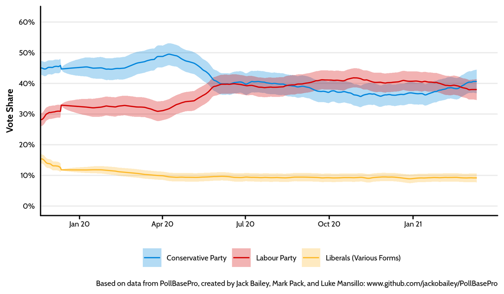

As of 12 March 2021, we estimate that **the Conservative Party has the largest base of support** with 41% (95% CI: 37% to 44%) of the electorate intending to vote for them at the next election. **They hold a lead over the Labour Party** of 3% (95% CI: -3% to 8%). **This puts the Labour Party in second place** on 38% (95% CI: 35% to 41%) of the vote. **In third place is the Liberal Democrats**, with support from 9% (95% CI: 8% to 11%) of voters.

## Notes, Usage, and Attribution

Both `pollbase` and `pollbasepro` are living datasets. As such, users should try to use only the most recent version of the data when conducting their analyses. Like any project of this size, we cannot rule out the possibility that minor mistakes might have crept into our data processing pipeline. If you think that you have found an error in our code or wish to make a recommendation for a future update, please [raise an issue](https://github.com/jackobailey/PollBasePro/issues) or contact us directly.

We are happy for others to use our code for their own purposes, but ask that they do so *with attribution*. That is, you may reproduce, reuse, and change the code here as you see fit, but must state in each case that you based your analysis on our work. The citations for each item in PollBasePro are as follows:

- **Data:** Bailey, J., M. Pack, and L. Mansillo (2021) PollBasePro: Daily Estimates of Aggregate Voting Intention in Great Britain from 1955 to 2021 v.0.1.0 [computer file], March 2021. Retrieved from doi.
- **Documentation:** Bailey, J., M. Pack, and L. Mansillo (2021) PollBasePro v0.1.0: User Guide and Codebook. Retrieved from doi.
- **Paper:** Bailey, J., M. Pack, and L. Mansillo (2021) PollBasePro: Daily Estimates of Aggregate Voting Intention in Great Britain from 1955 to 2021. Retrieved from doi.